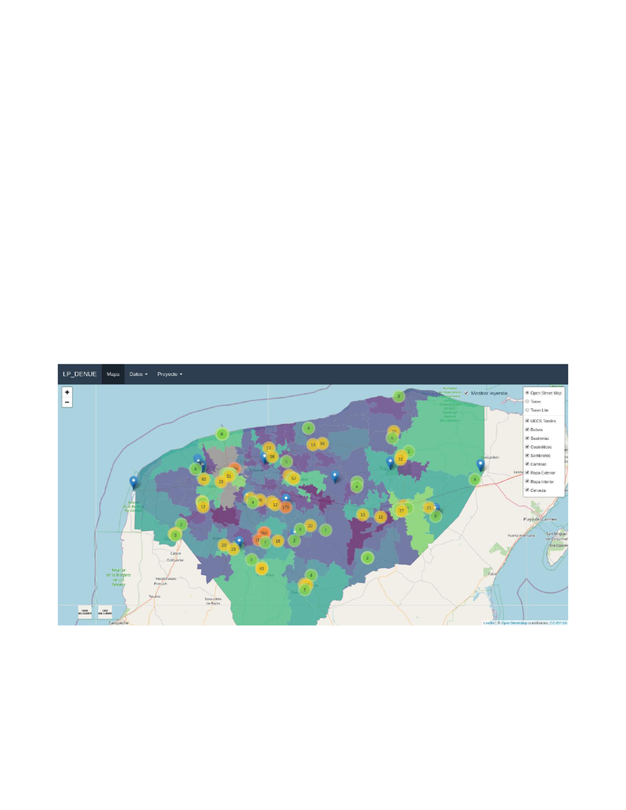

Plataforma de visualización de

información del DENUE para el

proyecto “X” Liverpool

ISKAR J. WALUYO MORENO

[figure not shown]

I. Presentación

I.1 Objetivos

Objetivo General: Desarrollar una plataforma con información y estadísticas sobre las actividades

económicas en Yucatán para facilitar la toma de decisiones sobre el proyecto “X” que busca incorporar

a proveedores locales a la empresa.

Objetivos Específicos:

 Establecer criterios para seleccionar cuales de los 804 tipos de actividades económicas en

Yucatán son relevantes para el proyecto

 Determinar las “categorías relevantes” para el proyecto

 Agrupar los establecimientos según su “categoría relevante” del punto anterior

 Elaborar una plataforma que permita:

 Filtrar los establecimientos relevantes por tamaño, municipio y categoría de actividad

 Visualizar en un mapa la ubicación, tamaño, actividad, localidad y datos de contacto de cada

establecimiento

NOTA: Existen 78 categorías que consideramos relevantes para el proyecto. El presente mapa se entrega sin costo como una

demostración. Solo contiene información de las siguientes 8 categorías productores de: 1) bolsas, 2) sastrerías, 3)

cosméticos, 4) sombreros, 5) camisas, 6) ropa “exterior”, 7) ropa interior y 8) cervezas.

II. Resumen general de resultados del demo

 Según el Directorio Estadístico Nacional de Unidades Económicas (DENUE) existen 804

distintos tipos de actividades económicas en Yucatán de las cuales consideramos que solo 78

eran relevantes para el “NOMBRE DEL PROYECTO”, de ahora en adalente PROYECTO en

un primer análisis exploratorio de los datos.

 En el DENUE se encontraron 130,018 establecimientos de los cuales 17,311 pertenecen a las 78

actividades consideradas relevantes para el PROYECTO para Liverpool ya que se trata de

mayoristas, productores y fabricantes. Muchos de ellos PyMES.

 Los listados completos de actividades y filtrados se anexan al presente documento.

II. Resumen del análisis de datos

II.1. Número de establecimientos según las personas ocupadas

El tamaño de los establecimientos es una característica importante para considerar al buscar

proveedores locales debido a que para participar en el PROYECTO. Deberán cumplir con un cierto

volumen de producción. Se considera importante analizar el tamaño de los establecimientos en función

del número de personas que ocupan. Se encontró que el 95% de los establecimientos son micro

negocios con 0 a 5 personas. Sin embargo, este es un dato general, valdría la pena analizar este dato por

cada categoría de actividad económica.

Tabla 1: Establecimientos según el número de personas ocupadas

Personas ocupadas en el establecimiento

Establecimientos

Porcentaje

0 a 5 personas

16535

95.52%

6 a 10 personas

483

2.79%

11 a 30 personas

184

1.06%

31 a 50 personas

41

0.24%

51 a 100 personas

20

0.12%

101 a 250 personas

29

0.17%

251 y más personas

19

0.11%

17311

100.00%

II.2 Número de unidades económicas por municipio

Yucatán esta dividido políticamente en 106 municipios. De esos, solo 11 de ellos tenían 400 o más

establecimientos posiblemente relevantes para el PROYECTO. Saber que municipios tienen una

cantidad importante de establecimientos por categoría de actividad económica, facilita encontrar zonas

de producción y la toma de decisiones sobre el proyecto.

Tabla 2: Número de unidades económicas por municipio en Yucatán

Municipio

Unidades Económicas

Porcentaje

1

Mérida

3031

17.51%

2

Tekit

1037

5.99%

3

Tekax

973

5.62%

4

Valladolid

821

4.74%

5

Teabo

780

4.51%

6

Tahdziú

773

4.47%

7

Izamal

716

4.14%

8

Oxkutzcab

532

3.07%

9

Ticul

480

2.77%

10

Maní

472

2.73%

11

Kanasín

444

2.56%

10059

58.11%

II.3 Hallazgos por tipo de actividad

En la presente demostración solo se analizan 8 de las 78 actividades que consideramos relevantes para

el PROYECTO. Las tablas de los resutlados se encuetran anexadas como archivos .csv que se pueden

consultar con un programa de Excel y se pueden consultar en la plataforma:

https://sigdatamx.shinyapps.io/LP_DENUE/

A continuación se presentan algunos de los hallazgos de la demostración consideramos relevantes para

el PROYECTO.

1. SOBRE LOS FABRICANTES DE BOLSAS

 Se encontraron 263 unidades económicas de producción de bolsas 252 de estas eran micro

empresas con 0 a 5 personas ocupadas. 9 de ellas eran empresas con 6 a 9 personas ocupadas.

 147 de 263 productores de bolsas se encuentran en el municipio de Huhí

2. SOBRE LAS SASTRERÍAS

 Se encontraron 941 sastrerías en el estado de las cuales la mayoría (925) ocupan a menos de 5

personas. 12 de los establecimientos ocupan entre 6 y 10 personas.

 Mérida, Tizimín, Valladolid, Tekit y Peto fueron los municipios con mas sastrerías, 141, 58, 54

y 50 respectivamente

3. SOBRE LOS FABRICANTES DE COSMÉTICOS

 Se encontraron 8 productores de cosméticos en el estado 6 en Mérida, 1 en Motul y otro en

Valladolid

 7 de 8 empresas de cosméticos ocupan a 5 o menos personas y una de ellas ocupa entre 50 y

100 personas

4. SOBRE LOS FABRICANTES DE SOMBREROS

 Se encontraron 5 productores de sombreros registrados en el DENUE en Yucatán. 4 de ellos

empresas con 5 personas ocupadas o menos 1 de ellos con 6 a 10 personas.

 4 de 5 productores se encuentran en Mérida y 1 en Valladolid.

5. SOBRE LOS FABRICANTES DE CAMISAS

 Se encontraron 548 productores de camisas registrados en el DENUE en Yucatán. La mayoría

(478) son productores pequeños con 5 o menos personas ocupadas. 44 productores ocupaban a

entre 6 y 10 personas.

 La mayoría de los productores de camisas se encuentran en los municipios de Tekit, Mayapán,

Mérida y Mama. Tekit destaca al ser sede de 452 de los 548 productores de camisas registrados.

6. SOBRE LOS FABRICANTES DE ROPA “EXTERIOR” (asi lo cataloga el DENUE)

 Existen 864 negocios registrados de producción y/o confeccíón de ropa exterior. 728 de ellos

ocupan a 5 o menos personas. 58 ocupan de 6 a 10 personas y 41 ocupan de 11 a 30 personas.

 297 estan ubicados en Tekit, 104 en Mérida y 45 en Mama

7. SOBRE LOS FABRICANTES DE ROPA INTERIOR

 Se encontraron registros de 46 productores y/o confeccionadores de ropa interior en el estado.

40 de ellos ocupan a 5 o menos empleados. 3 ocupan entre 100 y 250 empleados y 3 ocupan

entre 6 y 30 empleados.

 17 de los 46 productores de ropa interior se encuentran en el municipio de Mayapán, 7 en

Mérida, 5 en Valladolid y 4 en Akil y Tahdziú

8. SOBRE LOS PRODUCTORES DE CERVEZA

 Solo se encontraron 4 registros de productores de cerveza en el DENUE para Yucatán, sin

embargo se prevee que existen más. 2 productores de cerveza ocupan a 5 personas o menos.

Una 251 personas o más y otra 6 a 10 personas o más.

 3 productores se encuentran en Mérida y uno en Hunucmá

III. Recomendaciones para el PROYECTO

 El CLIENTE debe establecer criterios y categorías para asegurar un mejor filtrado de los

establecimientos.

 Mantener dos niveles de filtros para seleccoinar los establecimientos relevantes.

 De este primer análisis exploratorio de datos, se encontró que un gran número de productores de

camisas se concentran en el municipio de Tekit. Valdría la pena investigar a fondo esta situación

para el PROYECTO.

 El DENUE no siempre recaba datos de todos los establecimientos. Habiendo identificado los

establecimientos que parecen pueden ser proveedores. El siguiente paso sería hacer una

investigacion por internet, en cámaras de comercio y en los sitios mismos para conseguir datos

de contacto de cada proveedor en potencia.

 Tomar en cuenta que el 95% de los productores son independientes y pequeños y que habrá que

acompañar a muchos de ellos durante el proceso. Esto probablemente sea un indicador de que

existen cooperativas que operan en la zona y coordinan la producción de varios productores

independientes.

 Considerar trabajar con ONGs que promueven el desarrollo rural en la zona. Algunas

organizaciones como Fondo para la Paz frecuentemente operan como vínculos entre

productores y la industria.

IV. Productos entrgados al CLIENTE en el demo

1. Listado de actividades consideradas en el primer filtro (78 actividades)

2. Tablas con datos de las unidades económicas encontradas por categoría de actividad (8)

3. Tablas con información sobre número de unidades económicas encontradas por municipio

4. Tablas con información sobre número de unidades económicas encontradas por número de

personas ocupadas

5. Plataforma virtual con mapa interactivo y tabla interactiva para consultar los resultados del

demo

[figure not shown]

V. Propuesta económica

Se estima que se puede generar una plataforma más completa que incluye mapa, consulta de datos y

gráficas interactivas en 6 a 8 semanas. Se harían entregas parciales para que la información este

disponible conforme se vaya generando.

Tabla 3: Costo estimado para generar plataforma con los todos los datos del DENUE para

Yucatán (entre 8 y 12 grupos de categorías de actividades económicas)

Concepto

Descripción

Costo Unitario

Rubro

Cantidad

Subtotal

Almacenamiento*

Los datos deben almacenarse en algún servidor para

que la aplicación funcioné desde cualquier sitio.

$1,500.00

Servicio de

proveedor

externo

1 año

$1,500.00

Preparación de datos

Los datos deben ser configurados antes de hacer los

mapas. Se deben limpiar y transformar en dátos que

pueda oucpar la plataforma.

$100.00

Honorarios

85 lotes

$8,500.00

Desarrollo de

plataforma

Una plataforma por cada categoría de datos que se

determine en conjunto con el CLIENTE. Se estima que

se puden agrupar en 8 a 12 grupos de categorías de

actividades.

$2,500.00

Honorarios

10 plataformas (1 por

categoría)

$25,000.00

Servidor “Shiny”**

Shiny es el servidor basado en el lenguaje R que se

usa para crear la plataforma.

$9.00 USD / mes

Servicio de

proveedor

externo

12 meses

$2,160.00

Elaboración de

informes

Honorarios por hacer un resumen de los datos y horas

de consultoría.

$500.00

Honorarios

10 informes (1 por

categoría)

$5,000.00

SUBTOTAL

IVA INCUIDO

* Referencia de costos de hospedaje web: https://neubox.com/hosting

**Referencia de costos de servicio por hospedar una applicación de R: https://www.shinyapps.io/

VI. Acerca de nosotros

Iskar J. Waluyo Moreno – Ingeniero Ambiental y maestro en Diseño y Estudios Urbanos con

especialidades en geomática y ciencias de datos. Egresado de la UAM-Azcapotzalco y CentroGEO.

Cuenta con más de 5 años de experiencia como consultor independiente en proyectos de desarrollo

urbano y rural en la CDMX y San Luis Potosí. Ha publicado varios artículos sobre el uso de datos

libres y software de código abierto para la elaboración de mapás temáticos interactivos.

Luis García – Urbanista de la UNAM y futuro maestro en Geomática de CentroGEO. Cuenta con más

de 5 años de experiencia elaborando mapas temáticos para empresas que han colaborado en proyectos

como la recuperación del Canal Nacional en la CDMX, mapas temáticos para el análisis electoral y

recientemente para el Tren Maya.

Próximamente estaremos formalizando una consultoría que provee servicios de:

 Análisis de datos

 Análisis de datos geoespacial

 Elaboración de cartografía

 Elaboración de plataformas para el análisis de datos y análisis geoespacial